# Fleet Manager User Guide

Ben Formosa 11429074

# Introduction

Fleet Manager (FM) is a web-based system for recording travel. You can use it to track mileage in multiple vehicles for multiple drivers.

## Concepts

### Users

Each driver should track their own travel. Fleet Manager uses your existing user directory to allow drivers to sign in to Fleet Manager with their own usernames and passwords.  
Users can log travel as well as add and manage their own cars

### Administrators

Some users should be assigned the role of administrator, which allows them to add and modify any car.

### Cars

Each vehicle has its profile stored. This includes information about the car, such as its make, model and registration. Each car must be assigned a unique name.

#### Fleet cars

If a car belongs to the company, it is a fleet car.

#### Disabled cars

Once a car is no longer being used, it should be marked as disabled. This won’t delete the car or any data, but will hide it from most views.

### Trips

Each journey from one destination to another is referred to as a trip. This is recorded in Fleet Manager by entering the destination and the odometer reading of the car on arrival.

#### Garaging cars

If a car is kept overnight at an employee’s residence, it is garaged there.

#### Personal travel

If a trip is not for business purposes, it is a personal trip. If your businesses charges employees for personal travel in company vehicles, you can use this to produce a list of charges.  
Currently, updating the cost per unit of travel is not supported via the app. However, you can set the cost by editing a configuration file.

## Other notes

### Units of measurement

The odometer reading and distance measurements do not include any units, and no calculations or conversions assume a particular unit of measurement. You should ensure that all data entered uses a consistent unit of measurement.

### Licensing

Fleet Manager is free software, released under the MIT License. It includes other free software such as Ruby on Rails, without all of which this project would not exist.  
The license details are available in the LICENCE file.

# Installation

Fleet Manager is a [Ruby on Rails](http://rubyonrails.org/) application hosted with [Phusion Passenger Standalone](https://www.phusionpassenger.com/), which can be installed on many operating systems. The recommended way to install Fleet Manager is on a dedicated Ubuntu 14.04 computer.

## Overview

You can install Fleet Manager using an installer or manually. The installer only supports some operating systems.

### Database

Fleet Manager stores all data in a SQLite3 database, `db/production.sqlite3` under the app directory.

### Terms

**FM**

Fleet Manager

**App directory**

The directory in which Fleet Manager is installed, e.g. `/srv/rails/fm`

## Requirements

- Create a new user to install and run Fleet Manager.
- Install Ruby version 1.8.5 to 2.1.3.
- LDAP Directory server

### Operating System

While Fleet Manager should work on many GNU/Linux distributions, it has only been tested with Ubuntu 14.04.  
Some operating systems provide versions of Ruby which are not yet supported by Passenger. Currently, the latest supported version of Ruby is 2.1.3.

### Directory server

Fleet Manager requires a directory server to provide user authentication. This could be openLDAP, Microsoft Active Directory, Novell eDirectory or other LDAP-compatible directory. Fleet Manager must be able to communicate with the Directory server using LDAP.  
It is recommended to create a dedicated directory user for Fleet Manager to use to bind to the directory.

#### Directory server groups

To define directory users as Users or Administrators; create a group for each in your directory.  
Users must be added directly to these groups. Nested groups are not supported.

## Installing Fleet Manager

### Installing Fleet Manager with the installer

The installer is a script which does the following:

- Adds the Phusion Passenger apt repository and installs Phusion Passenger.
- Creates a user ‘fm’.
- Creates a self-signed certificate for the web server.
- Creates an init script.
- Installs Ruby and prerequisite software from apt.
- Installs Bundler using Gem
- Clones the Fleet Manager source from GitHub
- Installs required software using Bundler
- Configures a secret key for the application

To install Fleet Manager on Ubuntu:

1. Download and run the script. You will be prompted for your sudo password. The script will take approximately 15 minutes to complete.

   ```bash
   wget https://raw.githubusercontent.com/benformosa/fm/master/install/install.sh
   chmod +x install.sh
   ./install.sh
   ```

2. Configure the application. See Configuring Fleet Manager.  
   Edit `config/ldap.yml` under the app directory.
3. Set up the database. See Set up Database.  
   Run the script `install/setupdb.sh` under the app directory.
4. Start the application.

   ```bash
   /etc/init.d/fm start
   ```

#### Using the installer from behind a web proxy

If need to use a web proxy to access the web, configure the following:

- Set the `http_proxy` and `https_proxy` environment variables. Gem uses the same format as many other programs; for example, see the [documentation for wget](https://www.gnu.org/software/wget/manual/html_node/Proxies.html).

  ```bash
  export {http,https}_proxy=http://username:password@host:port/
  ```

- Configure the sudoers option `env_keep` to preserve the http_proxy and https_proxy environment variables. Refer to the [sudoers man page](http://www.sudo.ws/man/sudoers.man.html).

  ```
  Defaults env_keep += "http_proxy https_proxy"
  ```

### Installing Fleet Manager manually

To install Fleet Manager without the installer:

1. Create a user to install and run FM as. E.g. `fm`.  
   Set this user’s home directory to the app directory and add them to the sudoers group.

   ```bash
   sudo useradd --user-group fm --home-dir /srv/rails/fm --shell /bin/bash --groups sudo
   ```

2. Create the app directory, and change its owner to `fm`.

   ```bash
   sudo mkdir -p /srv/rails/fm
   sudo chown fm:fm /srv/rails/fm
   ```

3. Install `passenger` and `bundler` using `gem`

   ```bash
   sudo gem install passenger
   sudo gem install bundler
   ```

4. Become user `fm`.

   ```bash
   sudo su -l fm
   ```

5. As `fm`, copy the FM source files into the app directory.  
   You can either a download a zip archive and extract it here, or clone the project from GitHub.
6. As `fm`, install the software required by FM using bundler.

   ```bash
   bundle install
   ```

7. As `fm`, pre-compile static files. This prepares images, css and js to be delivered by the web server.

   ```bash
   RAILS_ENV=production bundle exec rake assets:precompile
   ```

8. Return to your normal user shell.

   ```bash
   exit
   ```

9. Set the `secret_key_base` in the file `config/initializers/secret_token.rb` under the app directory.  
   This is used for securely storing session information. See the [Ruby on Rails Security Guide](http://guides.rubyonrails.org/security.html#session-storage)

   ```bash
   echo "fm::Application.config.secret_key_base = \
     \"$(cd /srv/rails/fm && bundle exec rake secret)\"" | \
     sudo tee /srv/rails/fm/config/initializers/secret_token.rb > /dev/null
   ```

10. Copy the initscript and config file to `/etc` and set as executable.

    ```bash
    sudo cp /srv/rails/fm/install/initd-fm /etc/init.d/fm
    sudo chmod +x /etc/init.d/fm
    sudo cp /srv/rails/fm/install/etc-fm.sh /etc/fm.sh
    sudo chmod +x /etc/fm.sh
    ```

11. Obtain or generate an SSL certificate. E.g.

    ```bash
    openssl req -x509 -newkey rsa:2048 -days 365 -nodes \
      -keyout /etc/ssl/private/self-signed.key -out /etc/ssl/certs/self-signed.pem
    sudo chmod 600 /etc/ssl/certs/self-signed.pem
    sudo chmod 600 /etc/ssl/private/self-signed.key
    ```

12. Configure the application. See Configuring Fleet Manager.  
    Edit `config/ldap.yml` under the app directory.
13. Set up the database. See Set up Database.

    ```bash
    sudo /srv/rails/fm/install/setupdb.sh`
    ```

14. Start the application.

    ```bash
    /etc/init.d/fm start
    ```

## Configuring Fleet Manager

The Fleet Manager service can be configured with the configuration file `/etc/fm.sh`. This is a shell script which only sets variables.  
Configuration for the application itself is through configuration files in `config`, under the app directory.

### Configuring LDAP

It is essential to configure LDAP settings before setting up the database.

The file `config/ldap.yml` under the app directory defines FM’s connection to an LDAP server.

Set the following values in the **`authorizations`** section:

**`group_base`**

Base OU to search for groups.

**`required_groups`**

Array with the first item being the LDAP attribute name which records group members, and the second being the Distinguished Name of the group containing all FM users.

**`admin_group`**

Array with the first item being the LDAP attribute name which records group members, and the second being the Distinguished Name of the group containing all FM administrators.

Set the following values in the **`production`** section:

**`host`**

LDAP server hostname or IP address.

**`port`**

TCP port the LDAP service is listening on.

**`attribute`**

Name of the LDAP attribute that users will enter in the login field. For AD, this is usually `samaccountname`, for openLDAP; it’s usually `cn`.

**`base`**

Base OU to search for users.

**`admin_user`**

Distinguished name of the user with which to bind to the LDAP server.

**`admin_password`**

Plain-text password for `admin_user`.

**`ssl`**

LDAP encryption method. Options are `simple_tls`, `start_tls`, or `false` to disable LDAPS. See the [Net:LDAP Rubydoc](http://www.rubydoc.info/github/ruby-ldap/ruby-net-ldap/Net/LDAP:encryption)

#### LDAP Configuration Example

**`config/ldap.yml`**

```yaml
authorizations: &AUTHORIZATIONS
  group_base: cn=users,dc=example,dc=com
  required_groups:
   - [“member”, “cn=app_users,cn=users,dc=example,dc=com”]
  admin_group: cn=app_admins,cn=users,dc=example,dc=com

production
  host: ldap.example.com
  port: 389
  attribute: samaccountname
  base: cn=users,dc=example,dc=com
  admin_user: cn=app_bind,cn=users,dc=example,dc=com
  admin_password: secret
  ssl: false
  <<: *AUTHORIZATIONS
```

### Configuring personal trip cost

To set the cost for each unit of travel, edit the configuration file `config/initializers/default_settings.rb`.  
The default is $1.00 per unit of personal travel. replace **`1`** with the value you want to set.

```ruby
Settings.defaults[:cost_per_unit_distance] = 1
```

To update the value, stop Fleet Manager, edit the config file as above, clear Fleet Manager’s cache with `rake tmp:cache:clear` and start Fleet Manager again.

```bash
sudo /etc/init.d/fm stop
sudo vi /srv/rails/fm/config/initializers/default_settings.rb
sudo sudo --login --user=fm --set-home sh -c "bundle exec rake tmp:cache:clear"
sudo /etc/init.d/fm start
```

### Set up Database

Run the script `install/setupdb.sh` to initialise the database.  
Ensure that LDAP settings are configured and the LDAP server is available before running the script.

### Configuring HTTPS

Using HTTPS is recommended, but not required. If you installed FM with the installer, a self-signed SSL certificate was created for you, and FM will use this for HTTPS.  
Restart the application after making any changes to the configuration file.

#### Using your own SSL certificate

To use your own SSL certificate, edit the configuration file `/etc/fm.sh` and update the following lines with the paths to your SSL certificate and private key.

```bash
SSL_CERT=/etc/ssl/certs/self-signed.pem
SSL_KEY=/etc/ssl/private/self-signed.key
```

#### Disabling HTTPS

To serve the application over HTTP instead of HTTPS, edit the configuration file `/etc/fm.sh` and change the value of `SSL` to `false`.

```bash
SSL=false
```

Set the port to 80.

```bash
PORT=80
```

## Maintaining Fleet Manager

The Fleet Manager service can be controlled with the initscript `/etc/init.d/fm`.

### Starting Fleet Manager

To start the FM service:

```bash
sudo /etc/init.d/fm start
```

You will see a message like the following. Note that this contains useful info such as the address the web server is listening on and log file location.

```
Starting service…
=============== Phusion Passenger Standalone web server started ===============
PID file: /var/run/fm.pid
Log file: /var/log/fm.log
Environment: production
Accessible via: https://0.0.0.0:443/

Serving in the background as a daemon.
Problems? Check https://www.phusionpassenger.com/library/admin/standalone/troubleshooting/
===============================================================================
Service started
```

The first time you start FM, Phusion Passenger will download and set up a web server module for your system. You will see a message like

```
 --> Downloading a Phusion Passenger agent binary for your platform

 --> Installing Nginx 1.8.0 engine

--------------------------

 --> Compiling passenger_native_support.so for the current Ruby interpreter...
     (set PASSENGER_COMPILE_NATIVE_SUPPORT_BINARY=0 to disable)
     Compilation succesful. The logs are here:
     /tmp/passenger_native_support-1e4sumo.log
 --> passenger_native_support.so successfully loaded.
```

### Stopping Fleet Manager

To stop the FM service:

```bash
sudo /etc/init.d/fm stop
```

```
Stopping service…
Service stopped
```

### Restarting Fleet Manager

To restart FM:

```bash
sudo /etc/init.d/fm restart
```

This is the same as running the `stop` and `start` actions successively.  
If FM is already stopped, this action is the same as `start`.

### Checking if Fleet Manager is running

To determine if the FM service is running:

```
sudo /etc/init.d/fm status
```

If it is running, its PID and PID file will be reported.

```
Phusion Passenger Standalone is running on PID 25279, according to PID file /var/run/fm.pid
```

You will see this message if it is not running.

```
Phusion Passenger Standalone is not running, according to PID file /var/run/fm.pid
```

### Backing up Fleet Manager

To back up Fleet Manager’s data, stop the application, then copy the database file to a backup location.

```bash
sudo /etc/init.d/fm stop
sudo cp /srv/rails/fm/db/production.sqlite3 /path/to/backups/production_backup.sqlite3
sudo /etc/init.d/fm start
```

### Restoring from backup

To restore from a backup, stop the application, then copy the backup to `db/production.sqlite3` under the app directory.

```bash
sudo /etc/init.d/fm stop
sudo cp /path/to/backups/production_backup.sqlite3 /srv/rails/fm/db/production.sqlite3
sudo /etc/init.d/fm start
```

If you are restoring to a new installation, restore the database in place of performing the Set up database step.

## Updating Fleet Manager

When an update to Fleet Manager is released on GitHub, you can use the update script to download and install it. This script will download the update from GitHub, update any software dependencies, the database schema and static files.  
It’s advisable to take a backup of your database and configuration files before running an update.

```bash
sudo /srv/rails/fm/install/update.sh
```

## Uninstalling Fleet Manager

If you need to retain your Car, Trip and user data, backup the database before uninstalling.

### Uninstalling Fleet Manager with the uninstaller

If you installed FM with the installer, you can use the uninstaller to remove it.  
The uninstaller is a script which does the following:

- Warns you able what it will do.
- Prompts you to continue.
- Stops the FM service.
- Optionally backs up the database.
- Deletes the SSL certificate the installer generated.
- Deletes the initscript
- Deletes the app directory

To uninstall Fleet Manager:

1. Copy the script to your home directory and run it.

   ```bash
   cp /srv/rails/fm/install/uninstall.sh .
   chmod +x uninstall.sh
   ./uninstall.sh
   ```

2. Read the warning. Type *1* to continue with the uninstaller, or *2* to exit.

```
###########
#         #
# WARNING #
#         #
###########

This script will delete the following files and directories:
/etc/fm.sh
/etc/init.d/fm
/etc/ssl/certs/self-signed.key
/etc/ssl/certs/self-signed.pem
/srv/rails/fm

Are you sure you want to uninstall Fleet Manager?
1) Yes
2) No
#?
```

3. The size of the database and backup target are displayed. Type *1* to backup the database to your home directory, *2* to continue without making a backup, and *3* to exit the uninstaller.

```
Backup database (Size 24K) to /home/ben/fm-production-backup_1439893245.sqlite3 ?
Select Cancel to exit the uninstaller."
1) Yes
2) No
3) Cancel
#?
```

3. You will be prompted for your sudo password, uninstaller will run.
4. The uninstaller will suggest some other tasks you may want to complete manually. See Uninstalling Fleet Manager manually for details.

### Uninstalling Fleet Manager manually

If you installed FM manually or would prefer not to use the uninstaller, use this process to remove it.

1. Stop the FM service.
2. Remove the user `fm` if it is no longer required by another application.

   ```bash
   sudo userdel fm
   ```

3. Remove the app directory

   ```bash
   sudo rm -rf /srv/rails/fm
   ```

4. Uninstall passenger and bundler if they are no longer required by another application.

   ```bash
   sudo gem uninstall bundler
   sudo gem uninstall passenger
   ```

5. Remove the initscript and config file.

   ```bash
   sudo rm /etc/init.d/fm
   sudo rm /etc/fm.sh
   ```

6. Remove the SSL certificate and key if they are no longer required by another application. E.g.

   ```bash
   sudo rm /etc/ssl/certs/self-signed.pem
   sudo rm /etc/ssl/private/self-signed.key
   ```

7. Uninstall any prerequisite software which is no longer required. E.g.

   ```bash
   sudo apt-get remove ruby-dev zlib1g-dev libsqlite3-dev openssl git
   ```

## Troubleshooting

### Log files

Fleet Manager’s log is `log/production.log` under the app directory. This will show what the application is doing, such as receiving HTTP requests. Passenger has a separate log file `/var/log/fm.log`. This will show what the Passenger service is doing, such as starting and stopping the application.

### Troubleshooting running application

#### Web page loads but looks strange

**Symptoms:** Web pages use browser default style, no images or styles are loaded.  
If you attempt to sign out, you see a 404 error page.  
You may see log messages such as:

```
I, [2015-08-17T18:33:44.049755 #29405]  INFO -- : Started GET "/javascripts/application.js" for 192.168.1.26 at 2015-08-17 18:33:44 +1000
F, [2015-08-17T18:33:44.066944 #29405] FATAL -- :
ActionController::RoutingError (No route matches [GET] "/javascripts/application.js"):


I, [2015-08-17T18:34:15.734383 #29405]  INFO -- : Started GET "/users/sign_out" for 192.168.1.26 at 2015-08-17 18:34:15 +1000
F, [2015-08-17T18:34:15.741476 #29405] FATAL -- :
ActionController::RoutingError (No route matches [GET] "/users/sign_out"):
```

**Resolution:** The web server is not serving static files. Use `rake` to prepare the files to be delivered to clients

```bash
sudo --login --user=fm --set-home "RAILS_ENV=production bundle exec rake assets:precompile"
```

# Using Fleet Manager

## Navigating Fleet Manager

At the bottom of each page are links to the main pages, **Cars**, **Trips**, and **Reports**.  
Each page also has a sign out link.

### Signing in to Fleet Manager

To Sign in to Fleet Manager, you will need your directory account username and password. This account should be a member of the FM users group, see Configuring LDAP.

In a web browser, browse to Fleet Manager’s address. At the **Sign In** page, enter your username and password and click *Sign in*.

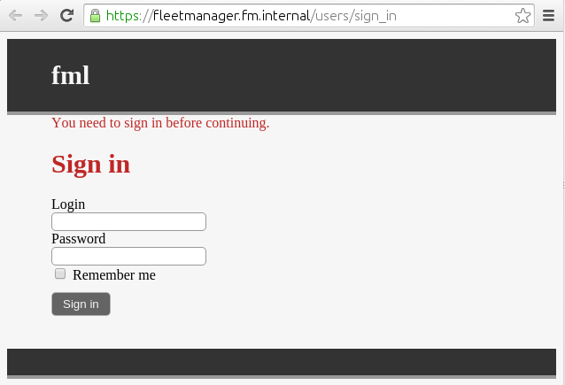

After signing in, you will be redirected to the **Cars** page.

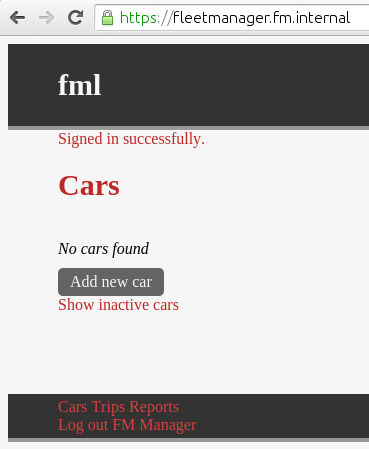

## Managing cars

### Adding a car

At the **Cars** page, click *Add new car*.  
Fill in the form with the details of the car and click *Create Car*.

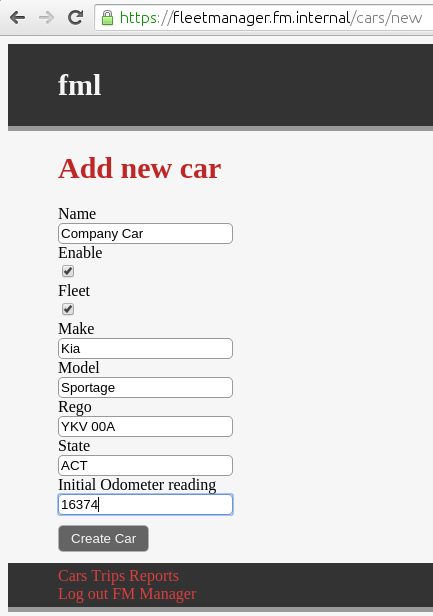

If one of fields is blank or entered incorrectly, you will see a message such as the following.

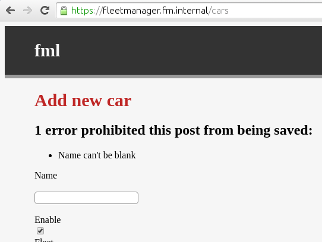

Cars are listed on the **Cars** page with their name and an icon. If Fleet Manager has a logo image for a car’s *Make*, it will be displayed as the icon.

### Viewing a car’s details

At the **Cars** page, click the name or image of a car to browse to its **car details** page. This page shows the car’s details.

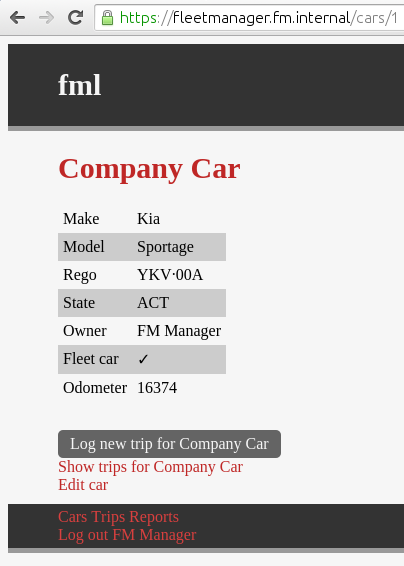

To see disabled cars, click *Show inactive cars* on the **Cars** page to switch to the disabled cars view.  
Click *Show active cars* to return to the standard view.

### Editing a car

To change a car’s details, click *Edit car* from the car details page.  
You can update details that were set when creating the car. Click *Update Car* to save changes.

### Disabling a car.

When a car is no longer in use, disable it by editing it and clearing the *Enable* check box.  
This will hide the car from the default view. There is no option to remove cars from the database.

## Logging travel

To record a journey, click *Log trip* under the car’s name on the **Cars** page, or *Log new trip for car name* from it’s **car details** page or **Trips** page.

Enter the location and odometer reading as at the end of the trip and click *Create Trip*.

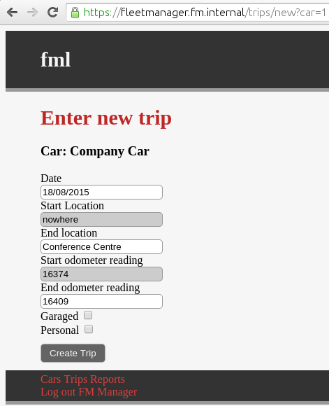

When entering a location, you can search previously used location by entering part of their name. a suggestion box will appear with matching locations. Click one of these suggestions to copy it to the location field.

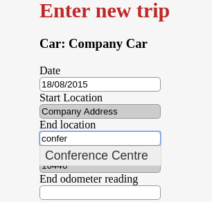

### Logging garaged cars

If the trip ends at an [employee’s residence](#garaging-cars] and will stay there overnight, check the *Garaged* checkbox when completing the form.

### Logging personal travel

If the trip is not for business purposes, check the *Personal* checkbox when completing the form.

## Viewing trips

The **Trips** page shows a table of all trips.  
To view trips for a single car, click that car’s name in the *Car* column.

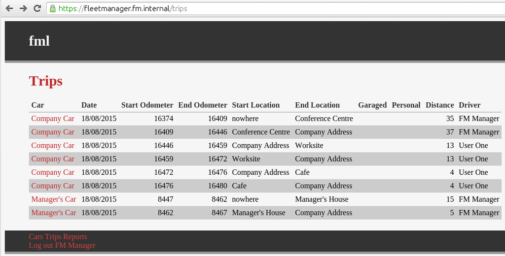

## Reports

The **Reports** page shows a list of available reports. Click the name of a report to see it.  
On the report page, click *Download CSV* for a copy of the report data in CSV format.

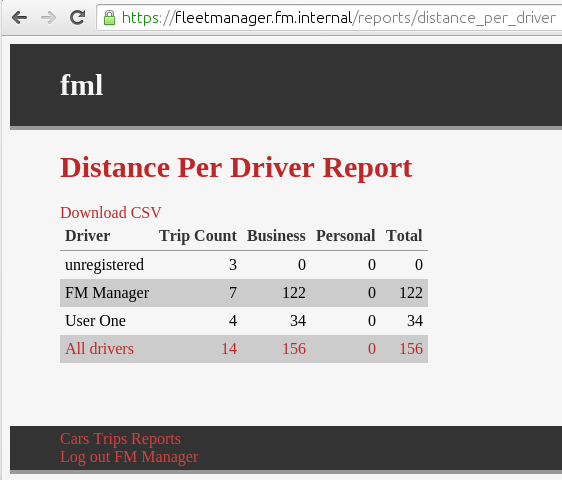